# supplement1

Steve Simon

March 24, 2018

This file creates various formulas and graphs needed to illustrate the underlying theory behind the data analyses in survival-lecture-1.Rmd. I am sharing this for those who are curious, but you are not responsible for learning or using the code shown in this supplement.

This file does not need any special libraries other than the ones listed below. Many of the data sets in this program use data from Hosmer, Lemeshow, and May. I made one minor change, however, which was to force all the variable names to lower case.

```r
library(broom)
library(dplyr)
```

```r
library(ggplot2)
library(knitr)
library(magrittr)
library(survival)
library(tidyr)
```

## Fruit fly data (round 1)

The fly1 data set is intended to illustrate how easy it would be for you to estimate a survival curve if you had no censoring. For a brief overview of this data, refer to data-dictionary-fly1in the doc folder.

To get the program to work properly, you need a variable that equals one for every observation, since every observation represents a time at death rather than a censoring time.

```r
fn <- "../data/fly1.txt"
fly1 <- read.table(fn, header=FALSE)
names(fly1) <- "time"
print(fly1)
```

```
##    time
## 1    37
## 2    40
## 3    43
## 4    44
## 5    45
## 6    47
## 7    49
## 8    54
## 9    56
## 10   58
## 11   59
## 12   60
## 13   61
## 14   62
## 15   68
## 16   70
## 17   71
## 18   72
## 19   73
## 20   75
## 21   77
## 22   79
## 23   89
## 24   94
## 25   96
```

```r
fly1$censor <- 1
fly1_surv <- Surv(fly1$time, fly1$censor)
fly1_km <- survfit(fly1_surv~1)
print(fly1_km)
```

```
## Call: survfit(formula = fly1_surv ~ 1)
##
##       n  events  median 0.95LCL 0.95UCL
##      25      25      61      56      73
```

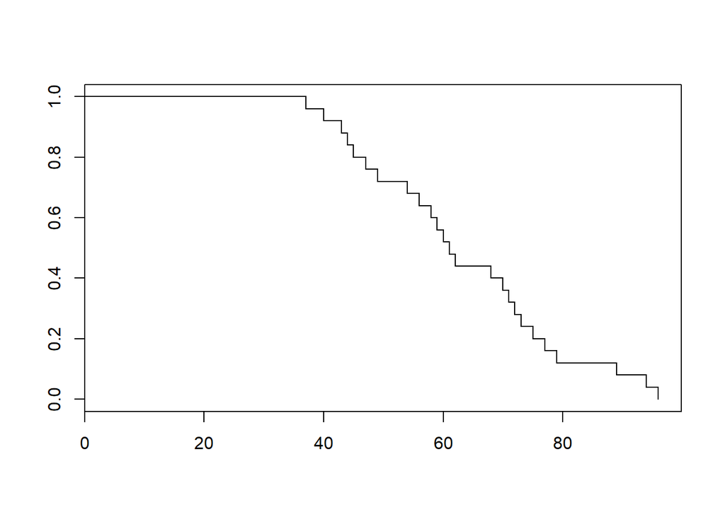

```r
plot(fly1_km, conf.int=FALSE)
```

## Fruit fly data (round 2)

The fly2 data set illustrates what happens to the data if a scientist accidentally let all the flies still alive at day 70 escape.

```r
fn <- "../data/fly2.txt"
fly2 <- read.table(fn, header=FALSE)
names(fly2) <- c("time", "censor")
print(fly2)
```

```
##    time censor
## 1    37      1
## 2    40      1
## 3    43      1
## 4    44      1
## 5    45      1
## 6    47      1
## 7    49      1
## 8    54      1
## 9    56      1
## 10   58      1
## 11   59      1
## 12   60      1
## 13   61      1
## 14   62      1
## 15   68      1
## 16   70      0
## 17   70      0
## 18   70      0
## 19   70      0
## 20   70      0
## 21   70      0
## 22   70      0
## 23   70      0
## 24   70      0
## 25   70      0
```

```r
fly2_surv <- Surv(fly2$time, fly2$censor)
fly2_km <- survfit(fly2_surv~1)
print(fly2_km)
```

```
## Call: survfit(formula = fly2_surv ~ 1)
##
##       n  events  median 0.95LCL 0.95UCL
##      25      15      61      56      NA
```

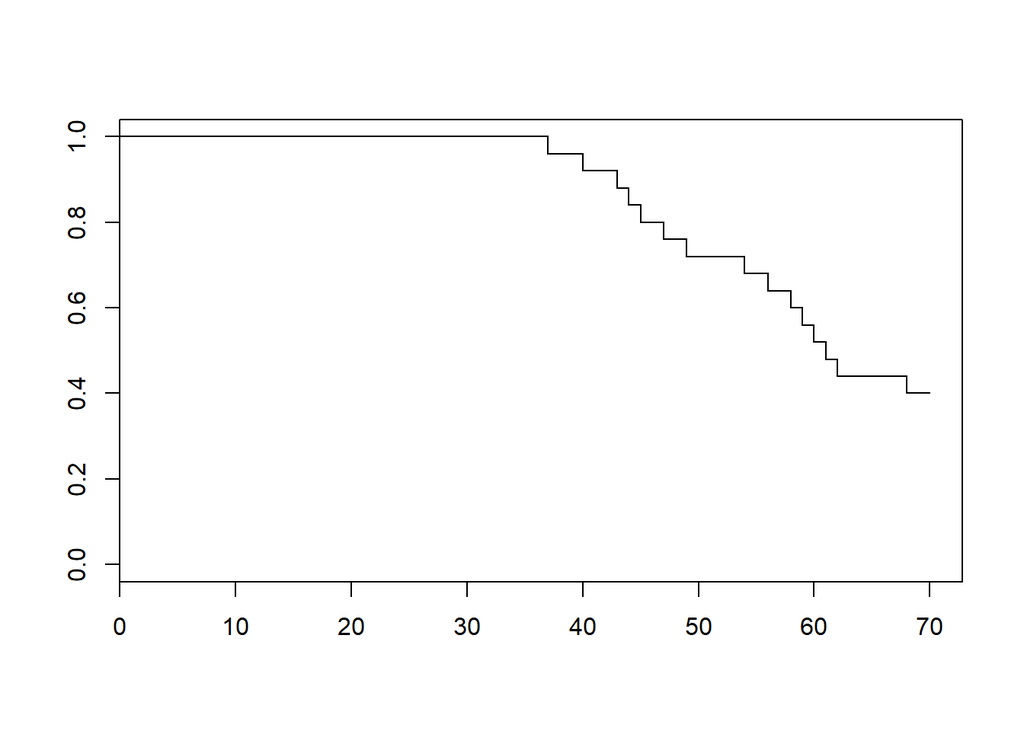

```r
plot(fly2_km, conf.int=FALSE)
```

## Fruit fly data (round 3)

The fly3 data set illustrates what happens to the data if a scientist accidentally let some (but not all) of the flies escape at day 70.

```r
fn <- "../data/fly3.txt"
fly3 <- read.table(fn, header=FALSE)
names(fly3) <- c("time", "censor")
print(fly3)
```

```
##    time censor
## 1    37      1
## 2    40      1
## 3    43      1
## 4    44      1
## 5    45      1
## 6    47      1
## 7    49      1
## 8    54      1
## 9    56      1
## 10   58      1
## 11   59      1
## 12   60      1
## 13   61      1
## 14   62      1
## 15   68      1
## 16   70      0
## 17   71      1
## 18   70      0
## 19   70      0
## 20   75      1
## 21   70      0
## 22   70      0
## 23   89      1
## 24   70      0
## 25   96      1
```

```r
fly3_surv <- Surv(fly3$time, fly3$censor)
fly3_km <- survfit(fly3_surv~1)
print(fly3_km)
```

```
## Call: survfit(formula = fly3_surv ~ 1)
##
##       n  events  median 0.95LCL 0.95UCL
##      25      19      61      56      NA
```

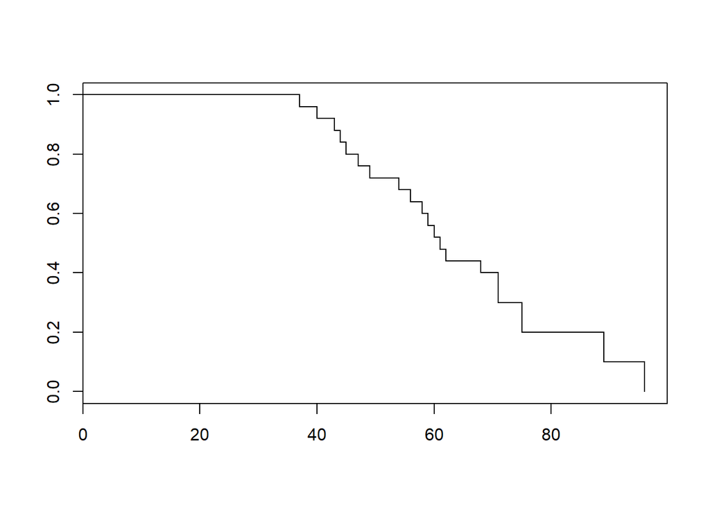

```r
plot(fly3_km, conf.int=FALSE)
```

## Hand calculation of Kaplan-Meier curve

Table 2.1 of Hosmer, Lemeshow, and May has a very small data set that you can use to calculate the Kaplan-Meier curve by hand. This code shows how R software would generate the graph, just so you can double check your work.

In R, you create a survival object with the Surv function. This object displays itself with every time listed, but with censored times followed with a plus sign. This is fairly standard shorthand.

The survfit function takes a survival object and produces information needed to draw one or more Kaplan-Meier curve. Using ~1 tells R that you want a single curve for all of the data.

```r
fn <- "../data/table21.txt"
table21 <- read.csv(fn, header=TRUE)
print(table21)
```

```
##   subject time censor
## 1       1    6      1
## 2       2   44      1
## 3       3   21      0
## 4       4   14      1
## 5       5   62      1
```

```r
table21_surv <- Surv(table21$time, table21$censor)
print(table21_surv)
```

```
## [1]  6  44  21+ 14  62
```

```r
table21_fit <- survfit(table21_surv~1)
print(table21_fit)
```

```
## Call: survfit(formula = table21_surv ~ 1)
##
##       n  events  median 0.95LCL 0.95UCL
##       5       4      44      14      NA
```

```r
summary(table21_fit)
```

```
## Call: survfit(formula = table21_surv ~ 1)
##
##  time n.risk n.event survival std.err lower 95% CI upper 95% CI
##     6      5       1      0.8   0.179       0.5161            1
##    14      4       1      0.6   0.219       0.2933            1
##    44      2       1      0.3   0.239       0.0631            1
##    62      1       1      0.0     NaN           NA           NA
```

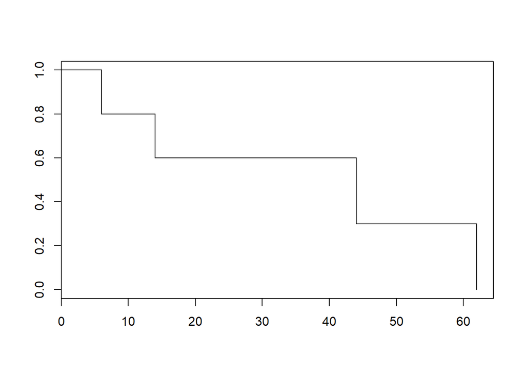

```r
plot(table21_fit, conf.int=FALSE)
```

## Kaplan-Meier curve using WHAS100 data

Read the data-dictionary-whas100.txt file in the doc subdirectory for information about this data set.

Out of respect for the book’s copyright, I am not reproducing the whas100.txt file in the git repository. See README.md in the main folder or the data dictionary file mentioned above for details about how to download this file.

The dotted lines in this graph show how to calculated the confidence limits for one of the quantiles.

```r
fn <- "../data/wiley/whas100.dat"
whas100 <- read.table(fn, header = FALSE)
names(whas100) <-
  c("id", "admitdate", "foldate",
    "los", "lenfol", "fstat",
    "age", "gender", "bmi")
whas100$time_yrs <- whas100$lenfol / 365.25
head(whas100)
```

```
##   id  admitdate    foldate los lenfol fstat age gender      bmi  time_yrs
## 1  1 03/13/1995 03/19/1995   4      6     1  65      0 31.38134 0.0164271
## 2  2 01/14/1995 01/23/1996   5    374     1  88      1 22.65790 1.0239562
## 3  3 02/17/1995 10/04/2001   5   2421     1  77      0 27.87892 6.6283368
## 4  4 04/07/1995 07/14/1995   9     98     1  81      1 21.47878 0.2683094
## 5  5 02/09/1995 05/29/1998   4   1205     1  78      0 30.70601 3.2991102
## 6  6 01/16/1995 09/11/2000   7   2065     1  82      1 26.45294 5.6536619
```

```r
whas100_surv <- Surv(whas100$time_yrs, whas100$fstat)
whas100_km <- survfit(whas100_surv~1)
par(mar=c(2.1, 2.1, 0.6, 0.6))
q <- quantile(whas100_km)
print(q)
```

```
## $quantile
##       25       50       75
## 1.796030 6.026010 7.419576
##
## $lower
##        25        50        75
## 0.7501711 4.9445585 7.1841205
##
## $upper
##       25       50       75
## 3.835729       NA       NA
```

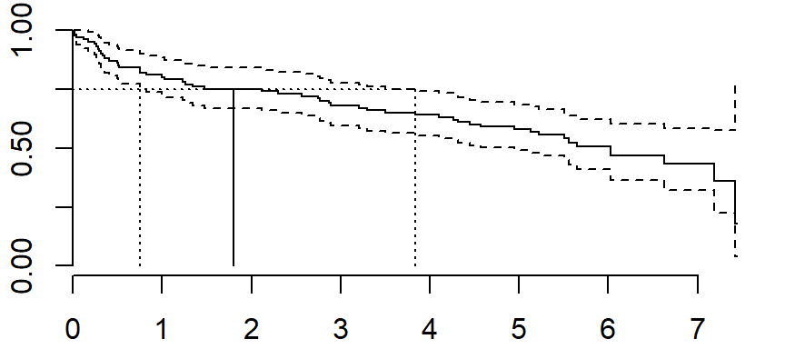

```r
plot(whas100_km, conf.int=TRUE, axes=FALSE)
axis(side=1)
axis(side=2, at=c(0, 0.25, 0.5, 0.75, 1))
segments(q$quantile[1], 0, q$quantile[1], 0.75)
segments(q$lower[1], 0, q$lower[1], 0.75, lty="dotted")
segments(q$upper[1], 0, q$upper[1], 0.75, lty="dotted")
segments(q$upper[1], 0.75, 0, 0.75, lty="dotted")
```

In my Powerpoint lecture, I had a few problems with notation and produced some confusion on how the logrank test actually works. Let me try again with this program.

This file does not need any special libraries other than the ones listed below.

Consider a small data set with the following survival times:

Male 6, 44+, 98, 114 Female 14, 44, 89+, 98, 104

To compare this properly, you need to create a table with the number of deaths, the number of censored values, and the number at risk, both overall and for the two groups.

First list the times in order. You can exclude times with only censored values, if you like.

Count the deaths in each group . d1i is deaths among the women, and d0i is deaths among the men.

| ti | d1i | d0i |
| --- | --- | --- |
| 6 | 0 | 1 |
| 14 | 1 | 0 |
| 44 | 1 | 0 |
| 89 | 0 | 0 |
| 98 | 1 | 1 |
| 104 | 1 | 0 |
| 114 | 0 | 1 |

Count the censored values in each group. This is not really necessary for computation, but it makes it a bit easier to follow the results.

Calculate the number at risk in each group.

| ti | d1i | c1i | n1i | d0i | c0i | n0i |
| --- | --- | --- | --- | --- | --- | --- |
| 6 | 0 | 0 | 5 | 1 | 0 | 4 |
| 14 | 1 | 0 | 5 | 0 | 0 | 3 |
| 44 | 1 | 0 | 4 | 0 | 1 | 3 |
| 89 | 0 | 1 | 3 | 0 | 0 | 2 |
| 98 | 1 | 0 | 2 | 1 | 0 | 2 |
| 104 | 1 | 0 | 1 | 0 | 0 | 1 |
| 114 | 0 | 0 | 0 | 1 | 0 | 1 |

Now calculate totals for both groups. You can drop group 0 and the censored values. Also drop the time point 89, which had only one censored value and no deaths.

|  | ti | d1i | n1i | di | ni |
| --- | --- | --- | --- | --- | --- |
| 1 | 6 | 0 | 5 | 1 | 9 |
| 2 | 14 | 1 | 5 | 1 | 8 |
| 3 | 44 | 1 | 4 | 1 | 7 |
| 5 | 98 | 1 | 2 | 2 | 4 |
| 6 | 104 | 1 | 1 | 1 | 2 |
| 7 | 114 | 0 | 0 | 1 | 1 |

So far, the only thing you have done is count, subtract, and add. Here’s where it gets a bit tricky.

If the two groups had equal survival probabilities, then you can estimate the conditional probability of death at $t_i$ as $p_i=\frac{d_i}{n_i}$. The expected number of deaths in the females is $n_{1i} p_i$. Calculate the observed number of deaths among the females minus the expected number of deaths.

|  | ti | d1i | n1i | di | ni | pi | e1i | o_minus_e |
| --- | --- | --- | --- | --- | --- | --- | --- | --- |
| 1 | 6 | 0 | 5 | 1 | 9 | 0.1111111 | 0.556 | -0.556 |
| 2 | 14 | 1 | 5 | 1 | 8 | 0.1250000 | 0.625 | 0.375 |
| 3 | 44 | 1 | 4 | 1 | 7 | 0.1428571 | 0.571 | 0.429 |
| 5 | 98 | 1 | 2 | 2 | 4 | 0.5000000 | 1.000 | 0.000 |
| 6 | 104 | 1 | 1 | 1 | 2 | 0.5000000 | 0.500 | 0.500 |
| 7 | 114 | 0 | 0 | 1 | 1 | 1.0000000 | 0.000 | 0.000 |

Notice that there is a mix of positive and negative numbers for the observed minus expected, but slightly more positive values. The total observed minus expected is 0.748.

If the death count were binomial, the variance at each time point would be $n_{1i} p_i (1-p_i)$ but you also have to adjust for the small sample sizes with a finite population correction factor, $\frac{n_i-n_{1i}}{n_i-1}$.

|  | ti | d1i | n1i | di | ni | pi | e1i | o_minus_e | vi |
| --- | --- | --- | --- | --- | --- | --- | --- | --- | --- |
| 1 | 6 | 0 | 5 | 1 | 9 | 0.1111111 | 0.556 | -0.556 | 0.247 |
| 2 | 14 | 1 | 5 | 1 | 8 | 0.1250000 | 0.625 | 0.375 | 0.234 |
| 3 | 44 | 1 | 4 | 1 | 7 | 0.1428571 | 0.571 | 0.429 | 0.245 |
| 5 | 98 | 1 | 2 | 2 | 4 | 0.5000000 | 1.000 | 0.000 | 0.333 |
| 6 | 104 | 1 | 1 | 1 | 2 | 0.5000000 | 0.500 | 0.500 | 0.250 |
| 7 | 114 | 0 | 0 | 1 | 1 | 1.0000000 | 0.000 | 0.000 | 0.000 |

The sum of the variances is 1.309 and you compare that to the square of the sum of observed minus expected 0.559504.

Save everything for possible re-use.

```r
save.image("../data/supplement1.RData")
```